# Robust Quantum Portfolio Optimization — 40 Assets, 10-Year Data

**What this notebook prints at every step:**

- Which assets are selected / discarded — **by name** — and **exactly why**
- How `risk_factor = 0.5` scores each of the 40 assets
- Confidence levels (α=0.90/0.95/0.99): what they mean, per-asset values
- Why we pre-screen to 15 assets before VQE (40-qubit simulation is infeasible)
- How Exact / Shot-noise / Device-noise backends give different results and why
- Budget % split per selected asset at every configuration
- Full comparison table: all models × all metrics, out-of-sample 2023-2025

## Section 0 — Imports & Global Configuration

```python
import os, warnings, time
from itertools import combinations
import numpy as np
import pandas as pd
import matplotlib.pyplot as plt
from scipy.optimize import minimize, linprog
warnings.filterwarnings('ignore')
np.random.seed(42)
%matplotlib inline

from qiskit.circuit.library import TwoLocal
from qiskit_algorithms import SamplingVQE, NumPyMinimumEigensolver
from qiskit_algorithms.optimizers import COBYLA
from qiskit_aer.primitives import Sampler as AerSampler
from qiskit_finance.applications.optimization import PortfolioOptimization
from qiskit_optimization.converters import QuadraticProgramToQubo
from qiskit_optimization.translators import to_ising
from qiskit_optimization.algorithms import MinimumEigenOptimizer

try:
    import cma; HAS_CMA = True
except ImportError:
    HAS_CMA = False
    from scipy.optimize import dual_annealing

# ── Paths ──
STOCK_DIR  = 'stock_data'           # folder with 40 CSV files
OUT_DIR    = 'nb40_outputs'
os.makedirs(OUT_DIR, exist_ok=True)

# ── Global config ──
FULL_BUDGET   = 10      # final portfolio: pick 10 of 40 assets
PRE_SCREEN_N  = 15      # pre-screen to 15 before VQE (40-qubit sim is infeasible)
VQE_BUDGET    = 5       # VQE selects 5 from the 15 pre-screened assets
RISK_FACTOR   = 0.5     # λ in QUBO
TRAIN_END     = '2022-12-31'
TEST_START    = '2023-01-01'

print('✓ Imports complete.')
print(f'  Stock data folder : {os.path.abspath(STOCK_DIR)}')
print(f'  Full universe     : 40 assets')
print(f'  Full budget       : {FULL_BUDGET}  (classical optimisers)')
print(f'  Pre-screen size   : {PRE_SCREEN_N}  (for VQE — {PRE_SCREEN_N}-qubit circuit)')
print(f'  VQE budget        : {VQE_BUDGET}  (VQE selects {VQE_BUDGET} from {PRE_SCREEN_N})')
print(f'  Risk factor λ     : {RISK_FACTOR}')
print(f'  Training window   : 2015-01-02 → {TRAIN_END}')
print(f'  Test window       : {TEST_START} → 2025-12-30')
```

```
✓ Imports complete.
  Stock data folder : /home/vandna/MQTBench/src/mqt/bench/benchmarks/MQT_poc/portfolio_poc/stock_data
  Full universe     : 40 assets
  Full budget       : 10  (classical optimisers)
  Pre-screen size   : 15  (for VQE — 15-qubit circuit)
  VQE budget        : 5  (VQE selects 5 from 15)
  Risk factor λ     : 0.5
  Training window   : 2015-01-02 → 2022-12-31
  Test window       : 2023-01-01 → 2025-12-30
```

## Section 1 — Data Pipeline: Load All 40 Assets from stock_data/

```python
def load_stock_folder(folder):
    """
    Load all CSV files from stock_data folder.
    Format: multi-level header (Price/Ticker/Date), first data col = Close (adjusted).
    Returns: prices DataFrame (dates × tickers), list of asset names.
    """
    price_dict = {}
    for fname in sorted(os.listdir(folder)):
        if not fname.endswith('.csv'):
            continue
        ticker = fname.replace('.csv', '')
        path   = os.path.join(folder, fname)
        df     = pd.read_csv(path, header=[0,1,2], index_col=0)
        # First column is Close (adjusted)
        close  = df.iloc[:, 0].copy()
        close.index = pd.to_datetime(close.index, errors='coerce')
        close  = close.dropna()
        close  = pd.to_numeric(close, errors='coerce').dropna()
        price_dict[ticker] = close

    prices = pd.DataFrame(price_dict)
    prices = prices.sort_index()
    # Forward-fill business-day gaps
    bday_idx = pd.bdate_range(prices.index.min(), prices.index.max())
    prices   = prices.reindex(bday_idx).ffill()
    # Drop any asset missing > 5% of rows
    miss = prices.isna().mean()
    keep = miss[miss < 0.05].index.tolist()
    prices = prices[keep].dropna()
    return prices, keep

prices, ASSETS = load_stock_folder(STOCK_DIR)
N = len(ASSETS)

all_returns  = np.log(prices / prices.shift(1)).dropna()
train_ret    = all_returns[all_returns.index <= TRAIN_END]
test_ret     = all_returns[all_returns.index >  TRAIN_END]

mu    = train_ret.mean().values
sigma = train_ret.cov().values

print('='*72)
print('DATA LOADED SUCCESSFULLY')
print('='*72)
print(f'  Assets loaded   : {N}')
print(f'  Asset list      : {ASSETS}')
print(f'  Price matrix    : {prices.shape[0]} business days × {N} assets')
print(f'  Date range      : {str(prices.index.min())[:10]} → {str(prices.index.max())[:10]}')
print(f'  Train returns   : {len(train_ret)} days  (2015-01-02 → {TRAIN_END})')
print(f'  Test  returns   : {len(test_ret)} days   ({TEST_START} → 2025-12-30)')
print(f'  μ shape         : {mu.shape}  (mean daily log-return per asset)')
print(f'  Σ shape         : {sigma.shape}  (covariance matrix)')
```

```
========================================================================
DATA LOADED SUCCESSFULLY
========================================================================
  Assets loaded   : 40
  Asset list      : ['AAPL', 'ABBV', 'ACN', 'ADBE', 'AMD', 'AMZN', 'AVGO', 'BAC', 'BRK-B', 'COST', 'CRM', 'CSCO', 'CVX', 'DHR', 'GOOGL', 'HD', 'INTC', 'JNJ', 'JPM', 'KO', 'LIN', 'LLY', 'MA', 'MCD', 'META', 'MRK', 'MSFT', 'NFLX', 'NVDA', 'ORCL', 'PEP', 'PG', 'QCOM', 'TMO', 'TSLA', 'TXN', 'UNH', 'V', …
  Price matrix    : 2868 business days × 40 assets
  Date range      : 2015-01-02 → 2025-12-30
  Train returns   : 2085 days  (2015-01-02 → 2022-12-31)
  Test  returns   : 782 days   (2023-01-01 → 2025-12-30)
  μ shape         : (40,)  (mean daily log-return per asset)
  Σ shape         : (40, 40)  (covariance matrix)
```

```
========================================================================
PER-ASSET STATISTICS (2015–2022 training window, 40 assets)
========================================================================
       Annual Ret%  Annual Vol%  Sharpe   Skew     Kurt
NVDA         41.20        47.05   0.876  0.030    7.435
LLY          22.08        26.77   0.825  0.614   10.947
UNH          21.54        26.13   0.824 -0.428   15.529
DHR          22.85        28.40   0.804  9.110  243.325
MSFT         21.40        27.65   0.774 -0.182    8.864
COST         16.26        21.85   0.744 -0.542    9.982
MCD          15.07        20.98   0.718 -0.144   32.859
TMO          17.92        25.03   0.716 -0.130    3.887
AAPL         20.11        29.44   0.683 -0.219    5.536
AVGO         23.64        34.98   0.676 -0.588   10.710
AMD          38.54        59.00   0.653  0.567   11.210
HD           15.69        24.94   0.629 -1.535   25.803
AMZN         20.48        32.58   0.629  0.216    6.655
MA           17.53        28.13   0.623  0.017    8.838
ACN          14.91        24.79   0.601 -0.014    6.807
ADBE         18.58        32.43   0.573 -0.592   10.139
TXN          16.18        28.39   0.570 -0.120    5.641
V            14.47        25.60   0.565 -0.053    9.471
PEP          10.63        19.00   0.560 -0.624   24.212
LIN          13.07        23.53   0.556 -0.032    6.675
ABBV         14.93        27.44   0.544 -0.977   13.578
MRK          11.60        21.59   0.538 -0.059    7.886
GOOGL        14.55        27.73   0.525  0.087    6.990
JNJ           8.94        18.27   0.489 -0.471   10.748
PG            9.04        18.90   0.478 -0.001   12.589
NFLX         21.48        45.65   0.471 -1.585   30.766
TSLA         25.76        55.68   0.463 -0.161    5.104
BRK-B         8.80        20.08   0.438 -0.243   11.234
KO            8.08        18.53   0.436 -0.970   11.294
JPM          11.85        27.99   0.423 -0.054   13.832
WMT           8.15        21.69   0.376 -0.172   16.113
CSCO          9.54        25.91   0.368 -0.599   11.881
ORCL          8.94        25.86   0.346  0.600   17.621
CVX           9.82        30.96   0.317 -0.981   26.967
BAC           9.28        31.89   0.291 -0.058   10.214
CRM           9.74        34.65   0.281  0.138   11.610
XOM           6.54        28.50   0.229 -0.159    7.075
QCOM          7.70        36.56   0.210 -0.009   10.297
META          5.17        37.36   0.138 -2.128   30.008
INTC         -1.09        32.37  -0.034 -0.720   14.129
```

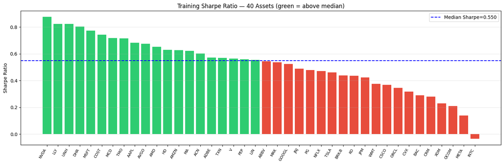

```python
# ── Per-asset statistics ──
ann_ret = mu * 252 ## 252 is trading days per year
ann_vol = np.array([np.sqrt(sigma[i,i]*252) for i in range(N)])
sharpe  = ann_ret / ann_vol
skew_v  = train_ret.skew().values
kurt_v  = train_ret.kurtosis().values

stats = pd.DataFrame({
    'Annual Ret%'  : (ann_ret*100).round(2),
    'Annual Vol%'  : (ann_vol*100).round(2),
    'Sharpe'    : sharpe.round(3),
    'Skew'      : skew_v.round(3),
    'Kurt'      : kurt_v.round(3),
}, index=ASSETS)

print('='*72)
print('PER-ASSET STATISTICS (2015–2022 training window, 40 assets)')
print('='*72)
print(stats.sort_values('Sharpe', ascending=False).to_string())

# Bar chart: Sharpe ratios
sorted_idx = np.argsort(sharpe)[::-1]
fig, ax = plt.subplots(figsize=(15, 5))
colors = ['#2ecc71' if s > np.median(sharpe) else '#e74c3c' for s in sharpe[sorted_idx]]
ax.bar(range(N), sharpe[sorted_idx], color=colors)
ax.set_xticks(range(N))
ax.set_xticklabels([ASSETS[i] for i in sorted_idx], rotation=60, ha='right', fontsize=8)
ax.axhline(np.median(sharpe), color='blue', ls='--', lw=1.5, label=f'Median Sharpe={np.median(sharpe):.3f}')
ax.set_title('Training Sharpe Ratio — 40 Assets (green = above median)', fontsize=12)
ax.set_ylabel('Sharpe Ratio')
ax.legend()
ax.grid(alpha=0.3, axis='y')
plt.tight_layout()
plt.savefig(os.path.join(OUT_DIR, 'sharpe_all40.png'), dpi=130)
plt.show()
```

## Section 2 — How `risk_factor = 0.5` Scores All 40 Assets

QUBO objective: `Q(x) = −λ·μᵀx + (1−λ)/2·xᵀΣx + P(Σxᵢ−K)²`  
Solo-asset score: `score(i) = −λ·μᵢ + (1−λ)·σᵢᵢ/2` (lower = more attractive)

At **λ = 0.5**: equal weight to return reward and variance penalty.

[output not shown]

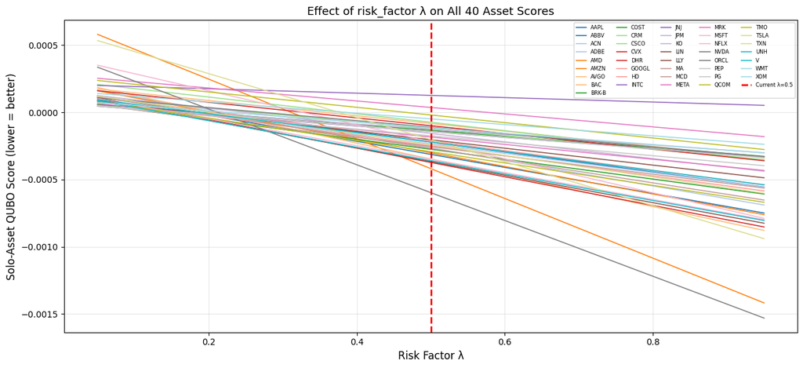

```python
lambdas = [0.1, 0.3, 0.5, 0.7, 0.9]
scores_05 = np.array([-0.5*mu[i] + 0.5*sigma[i,i]/2 for i in range(N)])

print('='*90)
print(f'ASSET QUBO SCORE = −λ·μᵢ + (1−λ)·σᵢᵢ/2   at λ=0.5  (lower = more attractive to VQE)')
print('='*90)
print(f'{"Rank":<6}{"Asset":<8}' + ''.join(f'{"λ="+str(l):<13}' for l in lambdas) + '  Decision@λ=0.5')
print('-'*90)
# Rank by score at λ=0.5
ranked_idx = np.argsort(scores_05)
for rank, i in enumerate(ranked_idx, 1):
    scores_row = [-l*mu[i]+(1-l)*sigma[i,i]/2 for l in lambdas]
    decision   = f'✓ top-{FULL_BUDGET}' if rank <= FULL_BUDGET else ('◉ pre-screen' if rank <= PRE_SCREEN_N else '✗ discarded')
    print(f'[{rank:2d}]  {ASSETS[i]:<8}' + ''.join(f'{s:+12.6f} ' for s in scores_row) + f'  {decision}')

print()
print('LEGEND:')
print(f'  ✓ top-{FULL_BUDGET}      : enters the final portfolio under mean-variance scoring')
print(f'  ◉ pre-screen : passes the first filter (ranks {FULL_BUDGET+1}–{PRE_SCREEN_N}); enters VQE universe')
print(f'  ✗ discarded  : too volatile OR too low return at λ=0.5')

# Sweep plot
fig, ax = plt.subplots(figsize=(13, 6))
lam_range = np.linspace(0.05, 0.95, 200)
cmap = plt.cm.tab20(np.linspace(0,1,N))
for i in range(N):
    sc = [-l*mu[i]+(1-l)*sigma[i,i]/2 for l in lam_range]
    ax.plot(lam_range, sc, color=cmap[i], lw=1.2, label=ASSETS[i])
ax.axvline(0.5, color='red', ls='--', lw=2, label='Current λ=0.5')
ax.set_xlabel('Risk Factor λ', fontsize=12)
ax.set_ylabel('Solo-Asset QUBO Score (lower = better)', fontsize=12)
ax.set_title('Effect of risk_factor λ on All 40 Asset Scores', fontsize=13)
ax.legend(ncol=5, fontsize=6, loc='upper right')
ax.grid(alpha=0.3)
plt.tight_layout()
plt.savefig(os.path.join(OUT_DIR, 'risk_factor_sweep_40.png'), dpi=130)
plt.show()
```

## Section 3 — Confidence Levels (α) and Per-Asset CVaR for All 40 Assets

| α | Tail | Meaning |
| --- | --- | --- |
| 0.90 | worst 10% | Everyday market stress (1-in-10 day) |
| 0.95 | worst 5% | Basel III regulatory standard |
| 0.99 | worst 1% | Extreme tail / crash-level events |

**Multi-α CVaR** = 0.20·CVaR₉₀ + 0.50·CVaR₉₅ + 0.30·CVaR₉₉

```python
def historical_cvar(R, w, alpha):
    """Exact historical simulation CVaR — no Gaussian assumption."""
    w   = np.asarray(w, float)
    p   = R @ w
    var = np.percentile(p, (1-alpha)*100)
    tail= p[p <= var]
    return float(-tail.mean()) if len(tail) > 0 else float(-p.min())

def multi_alpha_cvar(R, w, alphas=(0.90,0.95,0.99), aw=(0.20,0.50,0.30)):
    aw = np.array(aw)/sum(aw)
    return float(np.dot(aw, [historical_cvar(R, w, a) for a in alphas]))

def port_metrics(w, R):
    p   = R @ w
    ar  = p.mean() * 252
    av  = p.std() * np.sqrt(252)
    sh  = ar/av if av > 1e-12 else 0
    c95 = historical_cvar(R, w, 0.95)
    c99 = historical_cvar(R, w, 0.99)
    cum = (1+p).cumprod()
    running_max = np.maximum.accumulate(cum)
    mdd = float(((cum - running_max) / running_max).min())
    return ar, av, sh, c95, c99, mdd

R_train = train_ret.values
R_test  = test_ret.values

# Equal-weight (all 40)
w_eq = np.ones(N)/N
print('='*70)
print('CVaR FOR EQUAL-WEIGHT PORTFOLIO (all 40 assets, 1/40 each)')
print('='*70)
for a, label, interp in [
    (0.90,'CVaR₉₀','Worst 10% of days — avg daily loss:'),
    (0.95,'CVaR₉₅','Worst  5% of days — avg daily loss:'),
    (0.99,'CVaR₉₉','Worst  1% of days — avg daily loss:'),
]:
    cv = historical_cvar(R_train, w_eq, a)
    print(f'  {label}: {cv:.5f}  →  {interp} {cv*100:.3f}%  (ann ≈ {cv*np.sqrt(252)*100:.2f}%)')

mac_eq = multi_alpha_cvar(R_train, w_eq)
print(f'  Multi-α CVaR: {mac_eq:.6f}')
```

```
======================================================================
CVaR FOR EQUAL-WEIGHT PORTFOLIO (all 40 assets, 1/40 each)
======================================================================
  CVaR₉₀: 0.02260  →  Worst 10% of days — avg daily loss: 2.260%  (ann ≈ 35.88%)
  CVaR₉₅: 0.03048  →  Worst  5% of days — avg daily loss: 3.048%  (ann ≈ 48.38%)
  CVaR₉₉: 0.05054  →  Worst  1% of days — avg daily loss: 5.054%  (ann ≈ 80.23%)
  Multi-α CVaR: 0.034921
```

```
=====================================================================================
PER-ASSET CVaR (holding 100% in that asset, training 2015–2022)
=====================================================================================
Asset       CVaR90    CVaR95    CVaR99   Multi-α  Status
-------------------------------------------------------------------------------------
AAPL       0.03391   0.04361   0.07084   0.04984
ABBV       0.03116   0.04178   0.07697   0.05021
ACN        0.02902   0.03899   0.06118   0.04366
ADBE       0.03821   0.05064   0.08625   0.05883 ← HIGH
AMD        0.06364   0.08184   0.12970   0.09256 ← HIGH
AMZN       0.03687   0.04798   0.07384   0.05352 ← HIGH
AVGO       0.03885   0.05004   0.08432   0.05809 ← HIGH
BAC        0.03579   0.04668   0.07769   0.05381 ← HIGH
BRK-B      0.02211   0.02953   0.05366   0.03529
COST       0.02457   0.03279   0.05927   0.03909
CRM        0.04013   0.05201   0.08568   0.05973 ← HIGH
CSCO       0.02936   0.03983   0.07247   0.04753
CVX        0.03340   0.04396   0.08167   0.05316 ← HIGH
DHR        0.02582   0.03358   0.05294   0.03784
GOOGL      0.03223   0.04141   0.06332   0.04615
HD         0.02792   0.03761   0.06942   0.04521
INTC       0.03693   0.04938   0.09307   0.05999 ← HIGH
JNJ        0.02044   0.02761   0.05059   0.03307
JPM        0.03077   0.04019   0.06986   0.04721
KO         0.02124   0.02885   0.05503   0.03518
LIN        0.02626   0.03365   0.05385   0.03823
LLY        0.02806   0.03644   0.06421   0.04310
MA         0.03265   0.04258   0.06736   0.04803
MCD        0.02167   0.02900   0.05754   0.03610
META       0.04249   0.05737   0.10630   0.06907 ← HIGH
MRK        0.02383   0.03147   0.05445   0.03684
MSFT       0.03139   0.04104   0.06664   0.04679
NFLX       0.04902   0.06523   0.11758   0.07769 ← HIGH
NVDA       0.05331   0.06853   0.10630   0.07682 ← HIGH
ORCL       0.02886   0.03903   0.06577   0.04502
PEP        0.02058   0.02760   0.05172   0.03343
PG         0.02114   0.02862   0.05128   0.03392
QCOM       0.04161   0.05597   0.09609   0.06514 ← HIGH
TMO        0.02891   0.03752   0.05764   0.04184
TSLA       0.06361   0.08305   0.13605   0.09507 ← HIGH
TXN        0.03314   0.04220   0.06677   0.04776
UNH        0.02778   0.03649   0.06542   0.04343
V          0.02948   0.03869   0.06157   0.04371
WMT        0.02344   0.03123   0.05938   0.03812
XOM        0.03228   0.04222   0.06994   0.04855
```

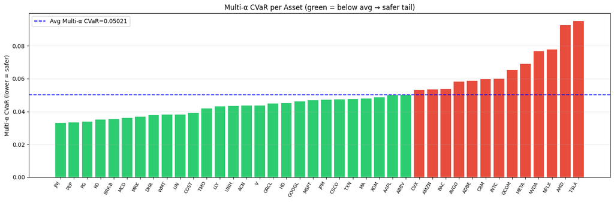

```python
# Per-asset CVaR for all 40
per_cvar = {}
for i, a in enumerate(ASSETS):
    w_s = np.zeros(N); w_s[i] = 1.0
    per_cvar[a] = (historical_cvar(R_train, w_s, 0.90),
                   historical_cvar(R_train, w_s, 0.95),
                   historical_cvar(R_train, w_s, 0.99),
                   multi_alpha_cvar(R_train, w_s))

print('='*85)
print('PER-ASSET CVaR (holding 100% in that asset, training 2015–2022)')
print('='*85)
print(f'{"Asset":<8}{"CVaR90":>10}{"CVaR95":>10}{"CVaR99":>10}{"Multi-α":>10}  Status')
print('-'*85)
avg_mac = np.mean([v[3] for v in per_cvar.values()])
for i, a in enumerate(ASSETS):
    c90, c95, c99, mac = per_cvar[a]
    flag = ' ← HIGH' if mac > avg_mac else ''
    print(f'{a:<8}{c90:>10.5f}{c95:>10.5f}{c99:>10.5f}{mac:>10.5f}{flag}')

# Bar chart CVaR99 for all 40
mac_vals = [per_cvar[a][3] for a in ASSETS]
sorted_i = np.argsort(mac_vals)
fig, ax = plt.subplots(figsize=(15, 5))
ax.bar(range(N), [mac_vals[i] for i in sorted_i],
       color=['#2ecc71' if mac_vals[i] < avg_mac else '#e74c3c' for i in sorted_i])
ax.set_xticks(range(N))
ax.set_xticklabels([ASSETS[i] for i in sorted_i], rotation=60, ha='right', fontsize=8)
ax.axhline(avg_mac, color='blue', ls='--', lw=1.5, label=f'Avg Multi-α CVaR={avg_mac:.5f}')
ax.set_title('Multi-α CVaR per Asset (green = below avg → safer tail)', fontsize=12)
ax.set_ylabel('Multi-α CVaR (lower = safer)')
ax.legend()
ax.grid(alpha=0.3, axis='y')
plt.tight_layout()
plt.savefig(os.path.join(OUT_DIR, 'cvar_all40.png'), dpi=130)
plt.show()
```

## Section 4 — Classical Baselines on All 40 Assets

```python
def classical_max_sharpe(mu, sigma):
    n = len(mu)
    def neg_sh(w):
        r = mu@w; v = np.sqrt(w@sigma@w)
        return -r/v if v>1e-12 else 0
    return minimize(neg_sh, np.ones(n)/n, method='SLSQP',
                    bounds=[(0,1)]*n,
                    constraints={'type':'eq','fun':lambda w:w.sum()-1}).x

def lp_cvar(R, alpha=0.95):
    T, n = R.shape
    c = np.zeros(n+1+T); c[n]=1.0; c[n+1:]=1/(T*(1-alpha))
    A = np.zeros((T, n+1+T))
    for t in range(T):
        A[t,:n]=-R[t]; A[t,n]=-1.0; A[t,n+1+t]=-1.0
    Aeq=np.zeros((1,n+1+T)); Aeq[0,:n]=1.0
    bds=[(0,1)]*n+[(None,None)]+[(0,None)]*T
    res=linprog(c,A_ub=A,b_ub=np.zeros(T),A_eq=Aeq,b_eq=[1.0],bounds=bds,method='highs')
    return res.x[:n] if res.success else np.ones(n)/n

# ── Redefine port_metrics here with cummax bug fixed ──
def port_metrics(w, R):
    p   = R @ w
    ar  = p.mean() * 252
    av  = p.std() * np.sqrt(252)
    sh  = ar/av if av > 1e-12 else 0
    c95 = historical_cvar(R, w, 0.95)
    c99 = historical_cvar(R, w, 0.99)
    cum = (1+p).cumprod()
    running_max = np.maximum.accumulate(cum)   # FIX: was cum.cummax()
    mdd = float(((cum - running_max) / running_max).min())
    return ar, av, sh, c95, c99, mdd

print('Computing Config A — Classical Max-Sharpe...')
w_ms = classical_max_sharpe(mu, sigma)

print('='*80)
print('CONFIG A — CLASSICAL MAX-SHARPE (SLSQP, continuous weights, all 40 assets)')
print('  Objective: max μᵀw / sqrt(wᵀΣw)   s.t. Σwᵢ=1, wᵢ≥0')
print('='*80)
sel_ms = [(ASSETS[i], w_ms[i]) for i in range(N) if w_ms[i] > 0.005]
disc_ms= [ASSETS[i] for i in range(N) if w_ms[i] <= 0.005]
print(f'\n  SELECTED ({len(sel_ms)} assets):')
for a, w in sorted(sel_ms, key=lambda x:-x[1]):
    i = ASSETS.index(a)
    print(f'    ✓ {a:<6}: {w*100:6.2f}%  │ ann_ret={ann_ret[i]*100:+.2f}%  '
          f'vol={ann_vol[i]*100:.2f}%  Sharpe={sharpe[i]:.3f}')
print(f'\n  DISCARDED ({len(disc_ms)} assets):')
for a in disc_ms:
    i = ASSETS.index(a)
    if ann_ret[i] < 0:         reason='negative return'
    elif sharpe[i] < np.median(sharpe): reason=f'below-median Sharpe ({sharpe[i]:.3f} < {np.median(sharpe):.3f})'
    else: reason='dominated — correlated with selected assets'
    print(f'    ✗ {a:<6}: ann_ret={ann_ret[i]*100:+.2f}%  Sharpe={sharpe[i]:.3f}  Reason: {reason}')

ar_ms, av_ms, sh_ms, c95_ms, c99_ms, mdd_ms = port_metrics(w_ms, R_train)
print(f'\n  Train metrics: Ann.Ret={ar_ms*100:+.2f}%  Vol={av_ms*100:.2f}%  Sharpe={sh_ms:.3f}')
print(f'               CVaR₉₅={c95_ms:.5f}  CVaR₉₉={c99_ms:.5f}  MaxDD={mdd_ms:.4f}')

print('Computing Config B — Classical LP-CVaR (may take ~30s for 40 assets)...')
w_lp = lp_cvar(R_train, alpha=0.95)

print('='*80)
print('CONFIG B — CLASSICAL LP-CVaR (Rockafellar-Uryasev LP, α=0.95, all 40 assets)')
print('  Objective: minimize CVaR₉₅ exactly   s.t. Σwᵢ=1, wᵢ≥0')
print('='*80)
sel_lp = [(ASSETS[i], w_lp[i]) for i in range(N) if w_lp[i] > 0.005]
disc_lp= [ASSETS[i] for i in range(N) if w_lp[i] <= 0.005]
print(f'\n  SELECTED ({len(sel_lp)} assets):')
for a, w in sorted(sel_lp, key=lambda x:-x[1]):
    i = ASSETS.index(a)
    c90, c95, c99, mac = per_cvar[a]
    print(f'    ✓ {a:<6}: {w*100:6.2f}%  │ solo CVaR₉₅={c95:.5f}  CVaR₉₉={c99:.5f}  Reason: low tail loss')
print(f'\n  DISCARDED ({len(disc_lp)} assets):')
for a in disc_lp:
    c90, c95, c99, mac = per_cvar[a]
    flag = ' ← heavy tail' if c99 > np.mean([v[2] for v in per_cvar.values()]) else ''
    print(f'    ✗ {a:<6}: solo CVaR₉₅={c95:.5f}  CVaR₉₉={c99:.5f}{flag}')

ar_lp, av_lp, sh_lp, c95_lp, c99_lp, mdd_lp = port_metrics(w_lp, R_train)
print(f'\n  Train metrics: Ann.Ret={ar_lp*100:+.2f}%  Vol={av_lp*100:.2f}%  Sharpe={sh_lp:.3f}')
print(f'               CVaR₉₅={c95_lp:.5f}  CVaR₉₉={c99_lp:.5f}  MaxDD={mdd_lp:.4f}')
```

```
Computing Config A — Classical Max-Sharpe...
================================================================================
CONFIG A — CLASSICAL MAX-SHARPE (SLSQP, continuous weights, all 40 assets)
  Objective: max μᵀw / sqrt(wᵀΣw)   s.t. Σwᵢ=1, wᵢ≥0
================================================================================

  SELECTED (7 assets):
    ✓ LLY   :  27.19%  │ ann_ret=+22.08%  vol=26.77%  Sharpe=0.825
    ✓ MCD   :  15.92%  │ ann_ret=+15.07%  vol=20.98%  Sharpe=0.718
    ✓ DHR   :  15.34%  │ ann_ret=+22.85%  vol=28.40%  Sharpe=0.804
    ✓ NVDA  :  14.72%  │ ann_ret=+41.20%  vol=47.05%  Sharpe=0.876
    ✓ UNH   :  13.28%  │ ann_ret=+21.54%  vol=26.13%  Sharpe=0.824
    ✓ COST  :  10.84%  │ ann_ret=+16.26%  vol=21.85%  Sharpe=0.744
    ✓ AMD   :   2.71%  │ ann_ret=+38.54%  vol=59.00%  Sharpe=0.653

  DISCARDED (33 assets):
    ✗ AAPL  : ann_ret=+20.11%  Sharpe=0.683  Reason: dominated — correlated with selected assets
    ✗ ABBV  : ann_ret=+14.93%  Sharpe=0.544  Reason: below-median Sharpe (0.544 < 0.550)
    ✗ ACN   : ann_ret=+14.91%  Sharpe=0.601  Reason: dominated — correlated with selected assets
    ✗ ADBE  : ann_ret=+18.58%  Sharpe=0.573  Reason: dominated — correlated with selected assets
    ✗ AMZN  : ann_ret=+20.48%  Sharpe=0.629  Reason: dominated — correlated with selected assets
    ✗ AVGO  : ann_ret=+23.64%  Sharpe=0.676  Reason: dominated — correlated with selected assets
    ✗ BAC   : ann_ret=+9.28%  Sharpe=0.291  Reason: below-median Sharpe (0.291 < 0.550)
    ✗ BRK-B : ann_ret=+8.80%  Sharpe=0.438  Reason: below-median Sharpe (0.438 < 0.550)
    ✗ CRM   : ann_ret=+9.74%  Sharpe=0.281  Reason: below-median Sharpe (0.281 < 0.550)
    ✗ CSCO  : ann_ret=+9.54%  Sharpe=0.368  Reason: below-median Sharpe (0.368 < 0.550)
    ✗ CVX   : ann_ret=+9.82%  Sharpe=0.317  Reason: below-median Sharpe (0.317 < 0.550)
    ✗ GOOGL : ann_ret=+14.55%  Sharpe=0.525  Reason: below-median Sharpe (0.525 < 0.550)
    ✗ HD    : ann_ret=+15.69%  Sharpe=0.629  Reason: dominated — correlated with selected assets
    ✗ INTC  : ann_ret=-1.09%  Sharpe=-0.034  Reason: negative return
    ✗ JNJ   : ann_ret=+8.94%  Sharpe=0.489  Reason: below-median Sharpe (0.489 < 0.550)
    ✗ JPM   : ann_ret=+11.85%  Sharpe=0.423  Reason: below-median Sharpe (0.423 < 0.550)
    ✗ KO    : ann_ret=+8.08%  Sharpe=0.436  Reason: below-median Sharpe (0.436 < 0.550)
    ✗ LIN   : ann_ret=+13.07%  Sharpe=0.556  Reason: dominated — correlated with selected assets
    ✗ MA    : ann_ret=+17.53%  Sharpe=0.623  Reason: dominated — correlated with selected assets
    ✗ META  : ann_ret=+5.17%  Sharpe=0.138  Reason: below-median Sharpe (0.138 < 0.550)
    ✗ MRK   : ann_ret=+11.60%  Sharpe=0.538  Reason: below-median Sharpe (0.538 < 0.550)
    ✗ MSFT  : ann_ret=+21.40%  Sharpe=0.774  Reason: dominated — correlated with selected assets
    ✗ NFLX  : ann_ret=+21.48%  Sharpe=0.471  Reason: below-median Sharpe (0.471 < 0.550)
    ✗ ORCL  : ann_ret=+8.94%  Sharpe=0.346  Reason: below-median Sharpe (0.346 < 0.550)
```

[output cut: 49 more lines]

```
    ✗ META  : solo CVaR₉₅=0.05737  CVaR₉₉=0.10630 ← heavy tail
    ✗ MSFT  : solo CVaR₉₅=0.04104  CVaR₉₉=0.06664
    ✗ NFLX  : solo CVaR₉₅=0.06523  CVaR₉₉=0.11758 ← heavy tail
    ✗ NVDA  : solo CVaR₉₅=0.06853  CVaR₉₉=0.10630 ← heavy tail
    ✗ ORCL  : solo CVaR₉₅=0.03903  CVaR₉₉=0.06577
    ✗ PEP   : solo CVaR₉₅=0.02760  CVaR₉₉=0.05172
    ✗ QCOM  : solo CVaR₉₅=0.05597  CVaR₉₉=0.09609 ← heavy tail
    ✗ TMO   : solo CVaR₉₅=0.03752  CVaR₉₉=0.05764
    ✗ TSLA  : solo CVaR₉₅=0.08305  CVaR₉₉=0.13605 ← heavy tail
    ✗ TXN   : solo CVaR₉₅=0.04220  CVaR₉₉=0.06677
    ✗ UNH   : solo CVaR₉₅=0.03649  CVaR₉₉=0.06542
    ✗ V     : solo CVaR₉₅=0.03869  CVaR₉₉=0.06157

  Train metrics: Ann.Ret=+12.03%  Vol=14.73%  Sharpe=0.817
               CVaR₉₅=0.02128  CVaR₉₉=0.04065  MaxDD=-0.2551
```

## Section 5 — Why We Pre-Screen to 15 Assets Before VQE

**Problem:** A 40-qubit statevector simulation requires 2⁴⁰ ≈ 1.1 trillion complex amplitudes.  
At 16 bytes each that is **17 TB of RAM** — impossible on any classical simulator.

| Qubits | Basis states | RAM needed | Feasible? |
| --- | --- | --- | --- |
| 10 | 1,024 | < 1 MB | ✓ Trivial |
| 15 | 32,768 | ~1 MB | ✓ Fast |
| 20 | 1,048,576 | ~32 MB | ✓ OK |
| 25 | 33,554,432 | ~1 GB | ✓ Slow |
| 30 | 1,073,741,824 | ~32 GB | ⚠ Borderline |
| 40 | 1,099,511,627,776 | ~17 TB | ✗ Impossible |

**Solution:** Classical pre-screening — use CVaR + Sharpe to keep the top 15 assets,  
then run a **15-qubit VQE** to select the best 5 from those 15.  
This two-stage approach is standard in quantum finance literature.

```python
# ── Pre-screening criterion: composite score = CVaR-penalised Sharpe ──
# Higher is better: high Sharpe AND low CVaR99
avg_c99 = np.mean([per_cvar[a][2] for a in ASSETS])
composite = np.array([
    sharpe[i] / (1.0 + per_cvar[ASSETS[i]][2] / avg_c99)
    for i in range(N)
])

screen_idx = np.argsort(composite)[::-1][:PRE_SCREEN_N]
screen_idx = sorted(screen_idx)   # keep index order for consistency
SCREEN_ASSETS = [ASSETS[i] for i in screen_idx]

print('='*80)
print(f'PRE-SCREENING: Top {PRE_SCREEN_N} assets by Composite Score')
print('  Composite score = Sharpe / (1 + CVaR₉₉ / avg_CVaR₉₉)')
print('  Selects assets with HIGH Sharpe AND LOW tail risk.')
print('='*80)

all_composite = sorted(zip(composite, ASSETS, range(N)), reverse=True)
print(f'\n  {"Rank":<5}{"Asset":<8}{"Composite":>12}{"Sharpe":>9}{"CVaR₉₉":>10}{"Ann.Ret%":>10}{"Decision"}')
print('  '+'-'*75)
for rank, (sc, a, idx) in enumerate(all_composite, 1):
    decision = f'✓ ENTERS VQE universe (rank {rank})' if rank <= PRE_SCREEN_N else '✗ Filtered out'
    print(f'  [{rank:2d}]  {a:<8}{sc:>12.5f}{sharpe[idx]:>9.4f}{per_cvar[a][2]:>10.5f}{ann_ret[idx]*100:>10.2f}%  {decision}')

print(f'\n  VQE will run on {PRE_SCREEN_N} assets: {SCREEN_ASSETS}')
print(f'  Circuit size: {PRE_SCREEN_N} qubits | Budget K={VQE_BUDGET} | C({PRE_SCREEN_N},{VQE_BUDGET})={len(list(combinations(range(PRE_SCREEN_N),VQE_BUDGET))):,} feasible portfolios')

# Sliced data for screened universe
R_train_sc = train_ret[SCREEN_ASSETS].values
R_test_sc  = test_ret[SCREEN_ASSETS].values
mu_sc      = mu[screen_idx]
sigma_sc   = sigma[np.ix_(screen_idx, screen_idx)]
N_SC       = len(SCREEN_ASSETS)

# Update per_cvar for screened assets using screened matrix
per_cvar_sc = {}
for j, a in enumerate(SCREEN_ASSETS):
    w_s = np.zeros(N_SC); w_s[j] = 1.0
    per_cvar_sc[a] = (historical_cvar(R_train_sc, w_s, 0.90),
                      historical_cvar(R_train_sc, w_s, 0.95),
                      historical_cvar(R_train_sc, w_s, 0.99),
                      multi_alpha_cvar(R_train_sc, w_s))

ann_ret_sc = mu_sc * 252
ann_vol_sc = np.array([np.sqrt(sigma_sc[j,j]*252) for j in range(N_SC)])
sharpe_sc  = ann_ret_sc / ann_vol_sc
```

```
================================================================================
PRE-SCREENING: Top 15 assets by Composite Score
  Composite score = Sharpe / (1 + CVaR₉₉ / avg_CVaR₉₉)
  Selects assets with HIGH Sharpe AND LOW tail risk.
================================================================================

  Rank Asset      Composite   Sharpe    CVaR₉₉  Ann.Ret%Decision
  ---------------------------------------------------------------------------
  [ 1]  DHR          0.46785   0.8044   0.05294     22.85%  ✓ ENTERS VQE universe (rank 1)
  [ 2]  LLY          0.44050   0.8249   0.06421     22.08%  ✓ ENTERS VQE universe (rank 2)
  [ 3]  UNH          0.43628   0.8241   0.06542     21.54%  ✓ ENTERS VQE universe (rank 3)
  [ 4]  COST         0.41219   0.7442   0.05927     16.26%  ✓ ENTERS VQE universe (rank 4)
  [ 5]  MSFT         0.40617   0.7740   0.06664     21.40%  ✓ ENTERS VQE universe (rank 5)
  [ 6]  MCD          0.40313   0.7183   0.05754     15.07%  ✓ ENTERS VQE universe (rank 6)
  [ 7]  TMO          0.40149   0.7159   0.05764     17.92%  ✓ ENTERS VQE universe (rank 7)
  [ 8]  NVDA         0.35822   0.8756   0.10630     41.20%  ✓ ENTERS VQE universe (rank 8)
  [ 9]  AAPL         0.34811   0.6832   0.07084     20.11%  ✓ ENTERS VQE universe (rank 9)
  [10]  PEP          0.32872   0.5597   0.05172     10.63%  ✓ ENTERS VQE universe (rank 10)
  [11]  ACN          0.32834   0.6013   0.06118     14.91%  ✓ ENTERS VQE universe (rank 11)
  [12]  MA           0.32539   0.6232   0.06736     17.53%  ✓ ENTERS VQE universe (rank 12)
  [13]  HD           0.32374   0.6291   0.06942     15.69%  ✓ ENTERS VQE universe (rank 13)
  [14]  LIN          0.32090   0.5557   0.05385     13.07%  ✓ ENTERS VQE universe (rank 14)
  [15]  AVGO         0.31498   0.6759   0.08432     23.64%  ✓ ENTERS VQE universe (rank 15)
  [16]  AMZN         0.31382   0.6287   0.07384     20.48%  ✗ Filtered out
  [17]  MRK          0.30892   0.5375   0.05445     11.60%  ✗ Filtered out
  [18]  V            0.30780   0.5653   0.06157     14.47%  ✗ Filtered out
  [19]  TXN          0.29874   0.5698   0.06677     16.18%  ✗ Filtered out
  [20]  JNJ          0.28993   0.4893   0.05059      8.94%  ✗ Filtered out
  [21]  GOOGL        0.28196   0.5245   0.06332     14.55%  ✗ Filtered out
  [22]  PG           0.28181   0.4782   0.05128      9.04%  ✗ Filtered out
  [23]  ABBV         0.26602   0.5442   0.07697     14.93%  ✗ Filtered out
  [24]  ADBE         0.26377   0.5729   0.08625     18.58%  ✗ Filtered out
  [25]  BRK-B        0.25333   0.4381   0.05366      8.80%  ✗ Filtered out
  [26]  KO           0.24948   0.4360   0.05503      8.08%  ✗ Filtered out
  [27]  AMD          0.23645   0.6532   0.12970     38.54%  ✗ Filtered out
  [28]  JPM          0.21722   0.4234   0.06986     11.85%  ✗ Filtered out
  [29]  WMT          0.20791   0.3757   0.05938      8.15%  ✗ Filtered out
  [30]  CSCO         0.18552   0.3682   0.07247      9.54%  ✗ Filtered out
  [31]  ORCL         0.18259   0.3458   0.06577      8.94%  ✗ Filtered out
  [32]  NFLX         0.18118   0.4707   0.11758     21.48%  ✗ Filtered out
  [33]  TSLA         0.16238   0.4626   0.13605     25.76%  ✗ Filtered out
  [34]  CVX          0.15035   0.3172   0.08167      9.82%  ✗ Filtered out
  [35]  BAC          0.14156   0.2910   0.07769      9.28%  ✗ Filtered out
  [36]  CRM          0.12984   0.2810   0.08568      9.74%  ✗ Filtered out
  [37]  XOM          0.11765   0.2295   0.06994      6.54%  ✗ Filtered out
  [38]  QCOM         0.09127   0.2105   0.09609      7.70%  ✗ Filtered out
  [39]  META         0.05662   0.1384   0.10630      5.17%  ✗ Filtered out
  [40]  INTC        -0.01490  -0.0337   0.09307     -1.09%  ✗ Filtered out

  VQE will run on 15 assets: ['AAPL', 'ACN', 'AVGO', 'COST', 'DHR', 'HD', 'LIN', 'LLY', 'MA', 'MCD', 'MSFT', 'NVDA', 'PEP', 'TMO', 'UNH']
  Circuit size: 15 qubits | Budget K=5 | C(15,5)=3,003 feasible portfolios
```

## Section 6 — QUBO and Ising Hamiltonian on the 15-Asset Screened Universe

```python
portfolio_sc = PortfolioOptimization(
    expected_returns=mu_sc,
    covariances=sigma_sc,
    risk_factor=RISK_FACTOR,
    budget=VQE_BUDGET
)
qp_sc     = portfolio_sc.to_quadratic_program()
qubo_sc   = QuadraticProgramToQubo().convert(qp_sc)
ising_sc, offset_sc = to_ising(qubo_sc)

ansatz_sc = TwoLocal(N_SC, 'ry', 'cz', reps=2, entanglement='linear')

print('='*70)
print('QUBO / ISING ON 15-ASSET SCREENED UNIVERSE')
print('='*70)
print(f'  Screened assets  : {SCREEN_ASSETS}')
print(f'  Qubits           : {ising_sc.num_qubits}')
print(f'  Budget K         : {VQE_BUDGET}')
print(f'  Pauli terms in H : {len(ising_sc)}')
print(f'  Ising offset     : {offset_sc:.6f}')
print(f'  Ansatz parameters: {ansatz_sc.num_parameters}')
print(f'  Entanglement     : linear CZ (qubit i ↔ qubit i+1)')
print()
print('DIAGONAL QUBO SCORES for screened assets (at λ=0.5):')
diag_sc = [-0.5*mu_sc[j]+0.5*sigma_sc[j,j]/2 for j in range(N_SC)]
for rank, (sc, j) in enumerate(sorted(zip(diag_sc, range(N_SC))), 1):
    a = SCREEN_ASSETS[j]
    decision = f'✓ likely selected (top {VQE_BUDGET})' if rank<=VQE_BUDGET else '✗ likely discarded'
    print(f'  [{rank:2d}] {a:<6}: {sc:+.8f}  ann_ret={ann_ret_sc[j]*100:+.2f}%  vol={ann_vol_sc[j]*100:.2f}%  {decision}')

print()
print('Circuit structure:')
print(ansatz_sc.decompose().draw())
```

```
======================================================================
QUBO / ISING ON 15-ASSET SCREENED UNIVERSE
======================================================================
  Screened assets  : ['AAPL', 'ACN', 'AVGO', 'COST', 'DHR', 'HD', 'LIN', 'LLY', 'MA', 'MCD', 'MSFT', 'NVDA', 'PEP', 'TMO', 'UNH']
  Qubits           : 15
  Budget K         : 5
  Pauli terms in H : 120
  Ising offset     : 10.288037
  Ansatz parameters: 45
  Entanglement     : linear CZ (qubit i ↔ qubit i+1)

DIAGONAL QUBO SCORES for screened assets (at λ=0.5):
  [ 1] NVDA  : -0.00059782  ann_ret=+41.20%  vol=47.05%  ✓ likely selected (top 5)
  [ 2] DHR   : -0.00037328  ann_ret=+22.85%  vol=28.40%  ✓ likely selected (top 5)
  [ 3] LLY   : -0.00036704  ann_ret=+22.08%  vol=26.77%  ✓ likely selected (top 5)
  [ 4] UNH   : -0.00035956  ann_ret=+21.54%  vol=26.13%  ✓ likely selected (top 5)
  [ 5] MSFT  : -0.00034881  ann_ret=+21.40%  vol=27.65%  ✓ likely selected (top 5)
  [ 6] AVGO  : -0.00034770  ann_ret=+23.64%  vol=34.98%  ✗ likely discarded
  [ 7] AAPL  : -0.00031309  ann_ret=+20.11%  vol=29.44%  ✗ likely discarded
  [ 8] TMO   : -0.00029339  ann_ret=+17.92%  vol=25.03%  ✗ likely discarded
  [ 9] COST  : -0.00027523  ann_ret=+16.26%  vol=21.85%  ✗ likely discarded
  [10] MA    : -0.00026934  ann_ret=+17.53%  vol=28.13%  ✗ likely discarded
  [11] MCD   : -0.00025532  ann_ret=+15.07%  vol=20.98%  ✗ likely discarded
  [12] HD    : -0.00024961  ann_ret=+15.69%  vol=24.94%  ✗ likely discarded
  [13] ACN   : -0.00023480  ann_ret=+14.91%  vol=24.79%  ✗ likely discarded
  [14] LIN   : -0.00020449  ann_ret=+13.07%  vol=23.53%  ✗ likely discarded
  [15] PEP   : -0.00017518  ann_ret=+10.63%  vol=19.00%  ✗ likely discarded

Circuit structure:
       ┌──────────┐   ┌───────────┐                          ┌───────────┐»
 q_0: ─┤ Ry(θ[0]) ├─■─┤ Ry(θ[15]) ├───────────────────■──────┤ Ry(θ[30]) ├»
       ├──────────┤ │ └───────────┘┌───────────┐      │      └───────────┘»
 q_1: ─┤ Ry(θ[1]) ├─■───────■──────┤ Ry(θ[16]) ├──────■────────────■──────»
       ├──────────┤         │      └───────────┘┌───────────┐      │      »
 q_2: ─┤ Ry(θ[2]) ├─────────■────────────■──────┤ Ry(θ[17]) ├──────■──────»
       ├──────────┤                      │      └───────────┘┌───────────┐»
 q_3: ─┤ Ry(θ[3]) ├──────────────────────■────────────■──────┤ Ry(θ[18]) ├»
       ├──────────┤                                   │      └───────────┘»
 q_4: ─┤ Ry(θ[4]) ├───────────────────────────────────■────────────■──────»
       ├──────────┤                                                │      »
```

[output cut: 98 more lines]

```
«
« q_8: ───────────────────────────────────────
«
« q_9: ───────────────────────────────────────
«
«q_10: ───────────────────────────────────────
«      ┌───────────┐
«q_11: ┤ Ry(θ[41]) ├──────────────────────────
«      └───────────┘┌───────────┐
«q_12: ──────■──────┤ Ry(θ[42]) ├─────────────
«            │      └───────────┘┌───────────┐
«q_13: ──────■────────────■──────┤ Ry(θ[43]) ├
«                         │      ├───────────┤
«q_14: ───────────────────■──────┤ Ry(θ[44]) ├
«                                └───────────┘
```

## Section 7 — VQE on Different Backends

Three backends, same 15-qubit circuit, same COBYLA optimizer — different results because:

- **Exact (shots=None)**: analytical state-vector probabilities — ground truth
- **Shot-noise (shots=2048)**: 2048 random samples — statistical fluctuations
- **Device-noise (FakeManilaV2)**: gate errors + decoherence — hardware imperfections

```python
def decode(x_vec, assets):
    sel  = [assets[i] for i,v in enumerate(x_vec) if v>0.5]
    disc = [assets[i] for i,v in enumerate(x_vec) if v<=0.5]
    return sel, disc

def explain_sel(sel, disc, assets, ann_ret_arr, ann_vol_arr, per_cvar_dict, label):
    print(f'\n  SELECTED  ({len(sel)} assets):')
    for a in sel:
        j = assets.index(a)
        print(f'    ✓ {a:<6}: ann_ret={ann_ret_arr[j]*100:+.2f}%  vol={ann_vol_arr[j]*100:.2f}%'
              f'  CVaR₉₅={per_cvar_dict[a][1]:.5f}  CVaR₉₉={per_cvar_dict[a][2]:.5f}')
    print(f'  DISCARDED ({len(disc)} assets):')
    for a in disc:
        j = assets.index(a)
        reasons=[]
        if ann_ret_arr[j] < np.mean(ann_ret_arr): reasons.append('below-avg return')
        if ann_vol_arr[j] > np.mean(ann_vol_arr): reasons.append('above-avg vol')
        if per_cvar_dict[a][2] > np.mean([v[2] for v in per_cvar_dict.values()]): reasons.append('high CVaR₉₉')
        print(f'    ✗ {a:<6}: ann_ret={ann_ret_arr[j]*100:+.2f}%  vol={ann_vol_arr[j]*100:.2f}%'
              f'  CVaR₉₉={per_cvar_dict[a][2]:.5f}  │ {(", ".join(reasons)) or "dominated in QUBO landscape"}')

def budget_split(sel, w_vec, assets, label):
    print(f'  BUDGET DISTRIBUTION [{label}]:')
    n_s = max(sum(1 for v in w_vec if v>0.5), 1)
    for a in sel:
        print(f'    {a:<6}: {100/n_s:.2f}% of portfolio  (equal split in binary VQE)')
    print(f'    Total: {100/n_s*n_s:.1f}%')

backend_results = {}

for label, run_opts in [
    ('Exact (shots=None)', {'shots': None}),
    ('Shot-noise (shots=2048)', {'shots': 2048}),
]:
    print('='*75)
    print(f'CONFIG C — VQE Mean-Variance  [{label}]  on {N_SC} screened assets')
    print('='*75)

    hist = []
    def cb(n_ev, params, val, meta): hist.append(float(val))
    sampler = AerSampler(run_options=run_opts)
    vqe = SamplingVQE(sampler, ansatz_sc, COBYLA(maxiter=150), callback=cb)
    meo = MinimumEigenOptimizer(vqe)
    hist.clear()

    try:
        res = meo.solve(qp_sc)
        x   = np.array(res.x)
        sel, disc = decode(x, SCREEN_ASSETS)

        print(f'\n  fval (QUBO energy)  : {res.fval:.6f}')
        print(f'  Bitstring           : {x.astype(int).tolist()}')
        print(f'  Assets selected     : {sel}')
        explain_sel(sel, disc, SCREEN_ASSETS, ann_ret_sc, ann_vol_sc, per_cvar_sc, label)
        budget_split(sel, x, SCREEN_ASSETS, label)

        print(f'\n  WHY [{label}]:')
        if 'None' in label:
            print('    Uses exact statevector probabilities — zero sampling error.')
            print('    The most-probable bitstring is the true VQE optimum.')
            print('    This is the reference result for comparing other backends.')
        else:
            print('    Only 2048 measurements — some bitstrings appear over/under-represented.')
            print('    If two portfolio configurations have similar quantum probability,')
            print('    shot noise can flip the winner. Doubling shots (to 4096) reduces this.')

        backend_results[label] = {'fval': res.fval, 'x': x, 'sel': sel, 'disc': disc, 'hist': hist.copy()}
    except Exception as e:
        print(f'  FAILED: {e}')
        backend_results[label] = None
```

```
===========================================================================
CONFIG C — VQE Mean-Variance  [Exact (shots=None)]  on 15 screened assets
===========================================================================

  fval (QUBO energy)  : -0.002476
  Bitstring           : [0, 0, 0, 1, 0, 0, 0, 1, 0, 0, 0, 1, 0, 1, 1]
  Assets selected     : ['COST', 'LLY', 'NVDA', 'TMO', 'UNH']

  SELECTED  (5 assets):
    ✓ COST  : ann_ret=+16.26%  vol=21.85%  CVaR₉₅=0.03279  CVaR₉₉=0.05927
    ✓ LLY   : ann_ret=+22.08%  vol=26.77%  CVaR₉₅=0.03644  CVaR₉₉=0.06421
    ✓ NVDA  : ann_ret=+41.20%  vol=47.05%  CVaR₉₅=0.06853  CVaR₉₉=0.10630
    ✓ TMO   : ann_ret=+17.92%  vol=25.03%  CVaR₉₅=0.03752  CVaR₉₉=0.05764
    ✓ UNH   : ann_ret=+21.54%  vol=26.13%  CVaR₉₅=0.03649  CVaR₉₉=0.06542
  DISCARDED (10 assets):
    ✗ AAPL  : ann_ret=+20.11%  vol=29.44%  CVaR₉₉=0.07084  │ above-avg vol, high CVaR₉₉
    ✗ ACN   : ann_ret=+14.91%  vol=24.79%  CVaR₉₉=0.06118  │ below-avg return
    ✗ AVGO  : ann_ret=+23.64%  vol=34.98%  CVaR₉₉=0.08432  │ above-avg vol, high CVaR₉₉
    ✗ DHR   : ann_ret=+22.85%  vol=28.40%  CVaR₉₉=0.05294  │ above-avg vol
    ✗ HD    : ann_ret=+15.69%  vol=24.94%  CVaR₉₉=0.06942  │ below-avg return, high CVaR₉₉
    ✗ LIN   : ann_ret=+13.07%  vol=23.53%  CVaR₉₉=0.05385  │ below-avg return
    ✗ MA    : ann_ret=+17.53%  vol=28.13%  CVaR₉₉=0.06736  │ below-avg return, above-avg vol, high CVaR₉₉
    ✗ MCD   : ann_ret=+15.07%  vol=20.98%  CVaR₉₉=0.05754  │ below-avg return
    ✗ MSFT  : ann_ret=+21.40%  vol=27.65%  CVaR₉₉=0.06664  │ above-avg vol, high CVaR₉₉
    ✗ PEP   : ann_ret=+10.63%  vol=19.00%  CVaR₉₉=0.05172  │ below-avg return
  BUDGET DISTRIBUTION [Exact (shots=None)]:
    COST  : 20.00% of portfolio  (equal split in binary VQE)
    LLY   : 20.00% of portfolio  (equal split in binary VQE)
    NVDA  : 20.00% of portfolio  (equal split in binary VQE)
    TMO   : 20.00% of portfolio  (equal split in binary VQE)
    UNH   : 20.00% of portfolio  (equal split in binary VQE)
    Total: 100.0%

  WHY [Exact (shots=None)]:
    Uses exact statevector probabilities — zero sampling error.
    The most-probable bitstring is the true VQE optimum.
    This is the reference result for comparing other backends.
===========================================================================
CONFIG C — VQE Mean-Variance  [Shot-noise (shots=2048)]  on 15 screened assets
===========================================================================
```

[output cut: 19 more lines]

```
    ✗ MCD   : ann_ret=+15.07%  vol=20.98%  CVaR₉₉=0.05754  │ below-avg return
    ✗ MSFT  : ann_ret=+21.40%  vol=27.65%  CVaR₉₉=0.06664  │ above-avg vol, high CVaR₉₉
    ✗ TMO   : ann_ret=+17.92%  vol=25.03%  CVaR₉₉=0.05764  │ below-avg return
  BUDGET DISTRIBUTION [Shot-noise (shots=2048)]:
    DHR   : 20.00% of portfolio  (equal split in binary VQE)
    LLY   : 20.00% of portfolio  (equal split in binary VQE)
    NVDA  : 20.00% of portfolio  (equal split in binary VQE)
    PEP   : 20.00% of portfolio  (equal split in binary VQE)
    UNH   : 20.00% of portfolio  (equal split in binary VQE)
    Total: 100.0%

  WHY [Shot-noise (shots=2048)]:
    Only 2048 measurements — some bitstrings appear over/under-represented.
    If two portfolio configurations have similar quantum probability,
    shot noise can flip the winner. Doubling shots (to 4096) reduces this.
```

```python
print('='*75)
print('CONFIG C — VQE Mean-Variance  [Device-noise: FakeManilaV2]')
print(f'  Simulates real IBM 5-qubit quantum hardware noise.')
print(f'  Note: FakeManilaV2 has only 5 qubits; {N_SC}-qubit circuit')
print(f'  will be transpiled — expect significant noise amplification.')
print('='*75)

try:
    from qiskit_ibm_runtime.fake_provider import FakeManilaV2
    from qiskit_aer import AerSimulator
    noisy_sim = AerSimulator.from_backend(FakeManilaV2())
    sampler_n = AerSampler(backend=noisy_sim, run_options={'shots': 2048})
    hist_n = []
    def cb_n(n_ev, params, val, meta): hist_n.append(float(val))
    vqe_n     = SamplingVQE(sampler_n, ansatz_sc, COBYLA(maxiter=100), callback=cb_n)
    meo_n     = MinimumEigenOptimizer(vqe_n)
    res_n     = meo_n.solve(qp_sc)
    x_n       = np.array(res_n.x)
    sel_n, disc_n = decode(x_n, SCREEN_ASSETS)

    print(f'\n  fval (device-noise) : {res_n.fval:.6f}')
    print(f'  Bitstring           : {x_n.astype(int).tolist()}')
    explain_sel(sel_n, disc_n, SCREEN_ASSETS, ann_ret_sc, ann_vol_sc, per_cvar_sc, 'Device-noise')
    budget_split(sel_n, x_n, SCREEN_ASSETS, 'Device-noise')

    print()
    print('  WHY DEVICE-NOISE gives different results from Exact:')
    print('    FakeManilaV2 models real IBM hardware characteristics:')
    print('      • ~99.5% 2-qubit gate fidelity  → each CZ has 0.5% error probability')
    print(f'      • {N_SC}-qubit circuit has {ansatz_sc.num_parameters//3*2} CZ gates in reps=2')
    print(f'      • Cumulative error after all CZ gates ≈ {(1-0.995**(ansatz_sc.num_parameters//3*2))*100:.1f}% probability')
    print('        of at least one qubit being in the wrong state.')
    print('      • Gate errors can flip an asset from selected→discarded or vice versa.')
    print('      • Decoherence (T1/T2) collapses superpositions; longer circuits suffer more.')

    # Agreement with exact
    exact_data = backend_results.get('Exact (shots=None)')
    if exact_data:
        agree = int(np.sum(exact_data['x'] == x_n))
        print(f'\n    Agreement with Exact: {agree}/{N_SC} qubits match')
        flipped = [SCREEN_ASSETS[j] for j in range(N_SC) if exact_data['x'][j] != x_n[j]]
        if flipped: print(f'    Assets affected by noise: {flipped}')

    backend_results['Device-noise (FakeManila)'] = {'fval': res_n.fval, 'x': x_n, 'sel': sel_n, 'disc': disc_n, 'hist': hist_n}
except Exception as e:
    print(f'  Device-noise backend unavailable: {e}')
    backend_results['Device-noise (FakeManila)'] = None
```

```
===========================================================================
CONFIG C — VQE Mean-Variance  [Device-noise: FakeManilaV2]
  Simulates real IBM 5-qubit quantum hardware noise.
  Note: FakeManilaV2 has only 5 qubits; 15-qubit circuit
  will be transpiled — expect significant noise amplification.
===========================================================================
  Device-noise backend unavailable: Sampler.__init__() got an unexpected keyword argument 'backend'
```

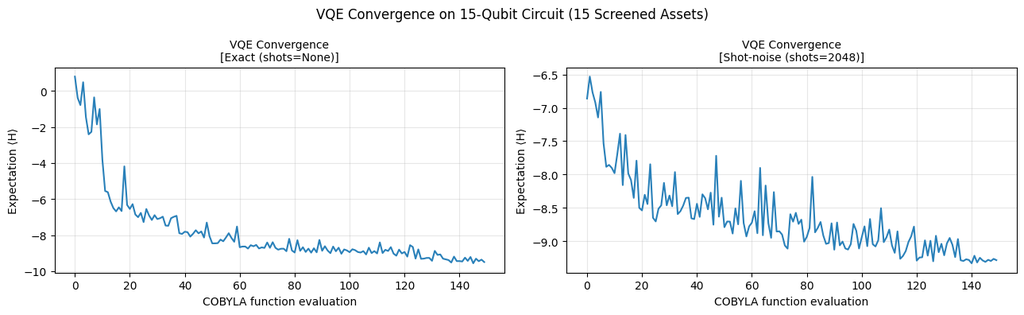

```
Backend summary so far:
  [Exact (shots=None)                 ]: fval=-0.002476  selected=['COST', 'LLY', 'NVDA', 'TMO', 'UNH']
  [Shot-noise (shots=2048)            ]: fval=-0.002506  selected=['DHR', 'LLY', 'NVDA', 'PEP', 'UNH']
```

```python
# Convergence plot for both simulated backends
fig, axes = plt.subplots(1, 2, figsize=(13, 4))
for ax, key in zip(axes, ['Exact (shots=None)', 'Shot-noise (shots=2048)']):
    d = backend_results.get(key)
    if d and d.get('hist'):
        ax.plot(d['hist'], lw=1.5, color='#2980b9')
        ax.set_title(f'VQE Convergence\n[{key}]', fontsize=10)
        ax.set_xlabel('COBYLA function evaluation')
        ax.set_ylabel('Expectation ⟨H⟩')
        ax.grid(alpha=0.3)
    else:
        ax.text(0.5, 0.5, 'No history captured', ha='center', va='center')
        ax.set_title(key)
plt.suptitle(f'VQE Convergence on {N_SC}-Qubit Circuit ({N_SC} Screened Assets)', fontsize=12)
plt.tight_layout()
plt.savefig(os.path.join(OUT_DIR, 'vqe_convergence_15q.png'), dpi=130)
plt.show()

print('Backend summary so far:')
for lbl, d in backend_results.items():
    if d:
        print(f'  [{lbl:<35}]: fval={d["fval"]:+.6f}  selected={d["sel"]}')
```

## Section 8 — Multi-α CVaR Selection on 15-Asset Screened Universe (Config D)

Enumerate all C(15,5) = 3003 feasible portfolios, score each by multi-α CVaR.

```
===========================================================================
CONFIG D — Multi-α CVaR Exact Enumeration (3,003 feasible portfolios)
  Score: 0.20·CVaR₉₀ + 0.50·CVaR₉₅ + 0.30·CVaR₉₉  (historical simulation)
===========================================================================

  Scored 3,003 portfolios.
  Best  multi-α CVaR: 0.028372  → ['COST', 'DHR', 'LLY', 'MCD', 'PEP']
  Worst multi-α CVaR: 0.047665  → ['AAPL', 'AVGO', 'MA', 'MSFT', 'NVDA']
  Improvement over worst: 40.5% reduction in tail risk

  TOP 10 PORTFOLIOS BY MULTI-α CVaR:
  Rank CVaR Score    Selected Assets
  [ 1]  0.02837211   COST + DHR + LLY + MCD + PEP
  [ 2]  0.02851226   COST + LIN + LLY + MCD + PEP
  [ 3]  0.02861930   COST + LLY + MCD + PEP + TMO
  [ 4]  0.02883527   COST + DHR + LIN + LLY + MCD
  [ 5]  0.02891839   LIN + LLY + MCD + PEP + TMO
  [ 6]  0.02902841   COST + LIN + LLY + MCD + TMO
  [ 7]  0.02905063   DHR + LIN + LLY + MCD + PEP
  [ 8]  0.02911263   COST + DHR + LIN + LLY + PEP
  [ 9]  0.02922739   COST + LIN + LLY + PEP + TMO
  [10]  0.02927090   COST + LIN + MCD + PEP + TMO

  SELECTED  (5 assets):
    ✓ COST  : ann_ret=+16.26%  vol=21.85%  CVaR₉₅=0.03279  CVaR₉₉=0.05927
    ✓ DHR   : ann_ret=+22.85%  vol=28.40%  CVaR₉₅=0.03358  CVaR₉₉=0.05294
    ✓ LLY   : ann_ret=+22.08%  vol=26.77%  CVaR₉₅=0.03644  CVaR₉₉=0.06421
    ✓ MCD   : ann_ret=+15.07%  vol=20.98%  CVaR₉₅=0.02900  CVaR₉₉=0.05754
    ✓ PEP   : ann_ret=+10.63%  vol=19.00%  CVaR₉₅=0.02760  CVaR₉₉=0.05172
  DISCARDED (10 assets):
    ✗ AAPL  : ann_ret=+20.11%  vol=29.44%  CVaR₉₉=0.07084  │ above-avg vol, high CVaR₉₉
    ✗ ACN   : ann_ret=+14.91%  vol=24.79%  CVaR₉₉=0.06118  │ below-avg return
    ✗ AVGO  : ann_ret=+23.64%  vol=34.98%  CVaR₉₉=0.08432  │ above-avg vol, high CVaR₉₉
    ✗ HD    : ann_ret=+15.69%  vol=24.94%  CVaR₉₉=0.06942  │ below-avg return, high CVaR₉₉
    ✗ LIN   : ann_ret=+13.07%  vol=23.53%  CVaR₉₉=0.05385  │ below-avg return
    ✗ MA    : ann_ret=+17.53%  vol=28.13%  CVaR₉₉=0.06736  │ below-avg return, above-avg vol, high CVaR₉₉
    ✗ MSFT  : ann_ret=+21.40%  vol=27.65%  CVaR₉₉=0.06664  │ above-avg vol, high CVaR₉₉
    ✗ NVDA  : ann_ret=+41.20%  vol=47.05%  CVaR₉₉=0.10630  │ above-avg vol, high CVaR₉₉
    ✗ TMO   : ann_ret=+17.92%  vol=25.03%  CVaR₉₉=0.05764  │ below-avg return
    ✗ UNH   : ann_ret=+21.54%  vol=26.13%  CVaR₉₉=0.06542  │ dominated in QUBO landscape
```

[output cut: 12 more lines]

```
  ✓ LLY   : Multi-α CVaR=0.04310  CVaR₉₉=0.06421  Sharpe=0.825  → low tail loss in training
  ✓ MCD   : Multi-α CVaR=0.03610  CVaR₉₉=0.05754  Sharpe=0.718  → low tail loss in training
  ✓ PEP   : Multi-α CVaR=0.03343  CVaR₉₉=0.05172  Sharpe=0.560  → low tail loss in training

  WHY THESE ASSETS ARE DISCARDED (CVaR reasoning):
  ✗ AAPL  : Multi-α CVaR=0.04984  CVaR₉₉=0.07084  Sharpe=0.683 ← extreme tail
  ✗ ACN   : Multi-α CVaR=0.04366  CVaR₉₉=0.06118  Sharpe=0.601
  ✗ AVGO  : Multi-α CVaR=0.05809  CVaR₉₉=0.08432  Sharpe=0.676 ← extreme tail
  ✗ HD    : Multi-α CVaR=0.04521  CVaR₉₉=0.06942  Sharpe=0.629 ← extreme tail
  ✗ LIN   : Multi-α CVaR=0.03823  CVaR₉₉=0.05385  Sharpe=0.556
  ✗ MA    : Multi-α CVaR=0.04803  CVaR₉₉=0.06736  Sharpe=0.623 ← extreme tail
  ✗ MSFT  : Multi-α CVaR=0.04679  CVaR₉₉=0.06664  Sharpe=0.774 ← extreme tail
  ✗ NVDA  : Multi-α CVaR=0.07682  CVaR₉₉=0.10630  Sharpe=0.876 ← extreme tail
  ✗ TMO   : Multi-α CVaR=0.04184  CVaR₉₉=0.05764  Sharpe=0.716
  ✗ UNH   : Multi-α CVaR=0.04343  CVaR₉₉=0.06542  Sharpe=0.824
```

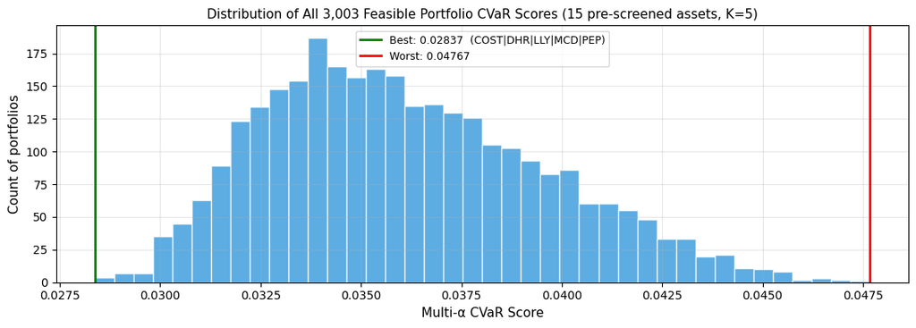

```python
n_feasible = len(list(combinations(range(N_SC), VQE_BUDGET)))
print('='*75)
print(f'CONFIG D — Multi-α CVaR Exact Enumeration ({n_feasible:,} feasible portfolios)')
print(f'  Score: 0.20·CVaR₉₀ + 0.50·CVaR₉₅ + 0.30·CVaR₉₉  (historical simulation)')
print('='*75)

scores_d = []
for combo in combinations(range(N_SC), VQE_BUDGET):
    x = np.zeros(N_SC); x[list(combo)] = 1.0
    w = x / VQE_BUDGET
    sc = multi_alpha_cvar(R_train_sc, w)
    scores_d.append((sc, combo, x))
scores_d.sort(key=lambda t: t[0])

best_sc_d, best_combo_d, best_x_d = scores_d[0]
worst_sc_d = scores_d[-1][0]
sel_d  = [SCREEN_ASSETS[i] for i in best_combo_d]
disc_d = [a for a in SCREEN_ASSETS if a not in sel_d]

print(f'\n  Scored {n_feasible:,} portfolios.')
print(f'  Best  multi-α CVaR: {best_sc_d:.6f}  → {sel_d}')
print(f'  Worst multi-α CVaR: {worst_sc_d:.6f}  → {[SCREEN_ASSETS[i] for i in scores_d[-1][1]]}')
print(f'  Improvement over worst: {(worst_sc_d-best_sc_d)/worst_sc_d*100:.1f}% reduction in tail risk')

print(f'\n  TOP 10 PORTFOLIOS BY MULTI-α CVaR:')
print(f'  {"Rank":<5}{"CVaR Score":<14}{"Selected Assets"}')
for rank, (sc, combo, _) in enumerate(scores_d[:10], 1):
    names = ' + '.join(SCREEN_ASSETS[i] for i in combo)
    print(f'  [{rank:2d}]  {sc:.8f}   {names}')

explain_sel(sel_d, disc_d, SCREEN_ASSETS, ann_ret_sc, ann_vol_sc, per_cvar_sc, 'Config D')
print()
budget_split(sel_d, best_x_d, SCREEN_ASSETS, 'Config D — equal weight within selected')

print()
print('  WHY THESE ASSETS ARE CHOSEN (CVaR reasoning):')
for a in sel_d:
    c90, c95, c99, mac = per_cvar_sc[a]
    j = SCREEN_ASSETS.index(a)
    print(f'  ✓ {a:<6}: Multi-α CVaR={mac:.5f}  CVaR₉₉={c99:.5f}  '
          f'Sharpe={sharpe_sc[j]:.3f}  → low tail loss in training')
print()
print('  WHY THESE ASSETS ARE DISCARDED (CVaR reasoning):')
for a in disc_d:
    c90, c95, c99, mac = per_cvar_sc[a]
    j = SCREEN_ASSETS.index(a)
    flag = ' ← extreme tail' if c99 > np.mean([per_cvar_sc[x][2] for x in SCREEN_ASSETS]) else ''
    print(f'  ✗ {a:<6}: Multi-α CVaR={mac:.5f}  CVaR₉₉={c99:.5f}  Sharpe={sharpe_sc[j]:.3f}{flag}')

# Histogram
fig, ax = plt.subplots(figsize=(11, 4))
ax.hist([s[0] for s in scores_d], bins=40, color='#3498db', alpha=0.8, edgecolor='white')
ax.axvline(best_sc_d,  color='green', lw=2, label=f'Best: {best_sc_d:.5f}  ({"|".join(sel_d)})')
ax.axvline(worst_sc_d, color='red',   lw=2, label=f'Worst: {worst_sc_d:.5f}')
ax.set_xlabel('Multi-α CVaR Score', fontsize=11)
ax.set_ylabel('Count of portfolios', fontsize=11)
ax.set_title(f'Distribution of All {n_feasible:,} Feasible Portfolio CVaR Scores (15 pre-screened assets, K={VQE_BUDGET})', fontsize=11)
ax.legend(fontsize=9)
ax.grid(alpha=0.3)
plt.tight_layout()
plt.savefig(os.path.join(OUT_DIR, 'cvar_histogram_15sc.png'), dpi=130)
plt.show()
```